# Import Libraries

# Data Preprocessing

## Handling Missing Value

```python
feature = ['recency','frequency','monetary']
```

```python
df[feature].isnull().sum()
```

```
recency        0
frequency      0
monetary     551
dtype: int64
```

```python
df.dropna(subset=feature,inplace=True)
```

```python
df[feature].isnull().sum()
```

```
recency      0
frequency    0
monetary     0
dtype: int64
```

## Handling Outlier

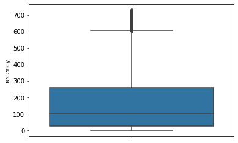

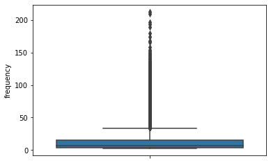

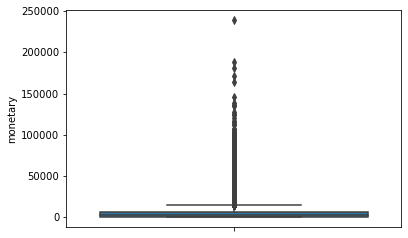

```python
for j in range (0,len(feature)):
    num = feature[j]
    sns.boxplot(y=df[num])
    plt.figure(figsize=(3,3))
    plt.show()
```

### IQR

```python
Q1 = df['recency'].quantile(0.25)
Q3 = df['recency'].quantile(0.75)
IQR = Q3-Q1
low_limit = Q1 - (1.5*IQR)
high_limit = Q3 + (1.5*IQR)
filtered_entries = ((df['recency']>=low_limit)&(df['recency']<=high_limit))
df_clean_IQR = df
df_clean_IQR = df_clean_IQR[filtered_entries]
df_clean_IQR.shape[0]
```

```
60278
```

```python
Q1 = df_clean_IQR['frequency'].quantile(0.25)
Q3 = df_clean_IQR['frequency'].quantile(0.75)
IQR = Q3-Q1
low_limit = Q1 - (1.5*IQR)
high_limit = Q3 + (1.5*IQR)
filtered_entries = ((df_clean_IQR['frequency']>=low_limit)&(df_clean_IQR['frequency']<=high_limit))
df_clean_IQR = df_clean_IQR[filtered_entries]
df_clean_IQR.shape[0]
```

```
55431
```

```python
Q1 = df_clean_IQR['monetary'].quantile(0.25)
Q3 = df_clean_IQR['monetary'].quantile(0.75)
IQR = Q3-Q1
low_limit = Q1 - (1.5*IQR)
high_limit = Q3 + (1.5*IQR)
filtered_entries = ((df_clean_IQR['monetary']>=low_limit)&(df_clean_IQR['monetary']<=high_limit))
df_clean_IQR = df_clean_IQR[filtered_entries]
df_clean_IQR.shape[0]
```

```
52407
```

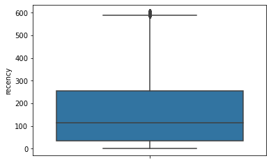

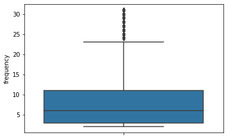

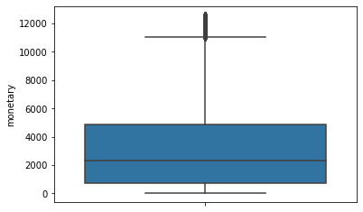

```python
for j in range (0,len(feature)):
    num = feature[j]
    sns.boxplot(y=df_clean_IQR[num])
    plt.figure(figsize=(3,3))
    plt.show()
```

**Data Insight**

outlier sudah berkurang

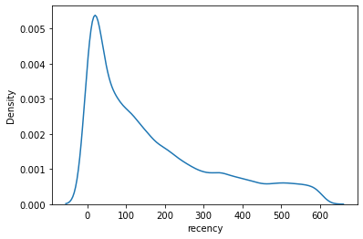

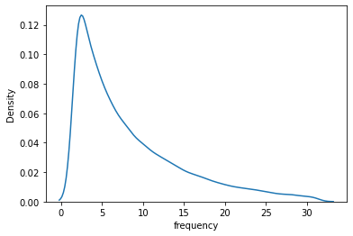

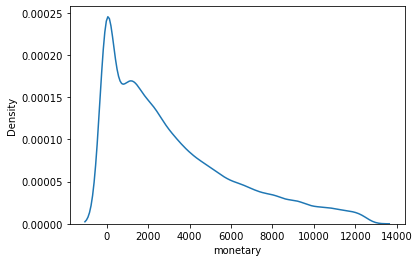

```python
for j in range (0,len(feature)):
    num = feature[j]
    sns.kdeplot(x=df_clean_IQR[num])
    plt.figure(figsize=(3,3))
    plt.show()
```

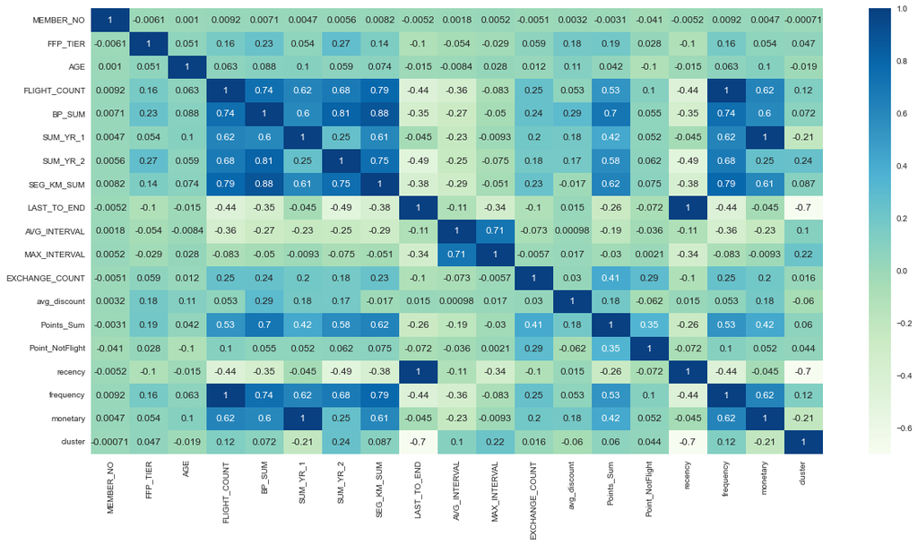

```python
numeric = df_clean_IQR.describe().columns.tolist()
df_corr = df_clean_IQR[numeric]
correlation = df_corr.corr()
plt.figure(figsize=(20,10))
sns.heatmap(correlation, cmap = "GnBu", annot = True)
```

```python
corr_matrix = df_clean_IQR.corr().abs()
upper = corr_matrix.where(np.triu(np.ones(corr_matrix.shape), k=1).astype(np.bool))
to_drop_hicorr = [column for column in upper.columns if any(upper[column] > 0.7)]
```

```python
to_drop_hicorr
```

```
['BP_SUM',
 'SUM_YR_2',
 'SEG_KM_SUM',
 'MAX_INTERVAL',
 'Points_Sum',
 'recency',
 'frequency',
 'monetary']
```

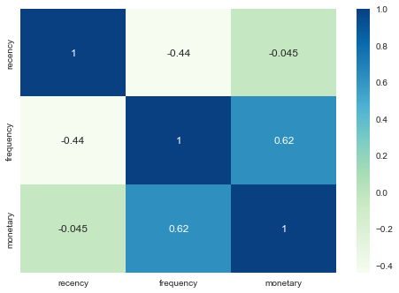

```python
df_corr = df_clean_IQR[feature]
correlation = df_corr.corr()
sns.heatmap(correlation, cmap = "GnBu", annot = True)
```

# Modeling

## RFM

```python
rfm_df = df_clean_IQR[feature]
```

```python
rfm_df
```

|  | recency | frequency | monetary |
| --- | --- | --- | --- |
| 94 | 51 | 12 | 12500.0 |
| 127 | 22 | 18 | 7444.0 |
| 175 | 22 | 14 | 0.0 |
| 362 | 13 | 23 | 12331.0 |
| 383 | 5 | 13 | 11050.0 |
| ... | ... | ... | ... |
| 62982 | 435 | 2 | 0.0 |
| 62983 | 295 | 2 | 0.0 |
| 62984 | 87 | 4 | 0.0 |
| 62985 | 28 | 2 | 0.0 |
| 62986 | 398 | 2 | 0.0 |

52407 rows × 3 columns

```python
from sklearn.preprocessing import StandardScaler
# scaling using standardization
scaler = StandardScaler()
scaler.fit(rfm_df['recency'].values.reshape(-1, 1))
rfm_df['recency'] = scaler.transform(rfm_df['recency'].values.reshape(-1, 1))

scaler = StandardScaler()
scaler.fit(rfm_df['frequency'].values.reshape(-1, 1))
rfm_df['frequency'] = scaler.transform(rfm_df['frequency'].values.reshape(-1, 1))


scaler = StandardScaler()
scaler.fit(rfm_df['monetary'].values.reshape(-1, 1))
rfm_df['monetary'] = scaler.transform(rfm_df['monetary'].values.reshape(-1, 1))
```

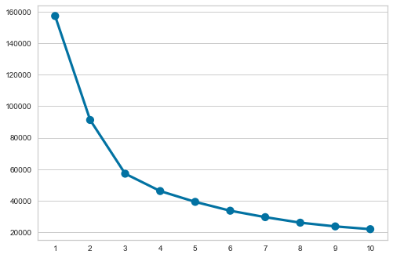

```python
from sklearn.cluster import KMeans
SSE = []
for k in range(0,10):
    kmeans = KMeans(n_clusters=k+1,random_state=43).fit(rfm_df)
    SSE.append(kmeans.inertia_)
sns.pointplot(x=list(range(1,11)),y=SSE)
plt.show()
```

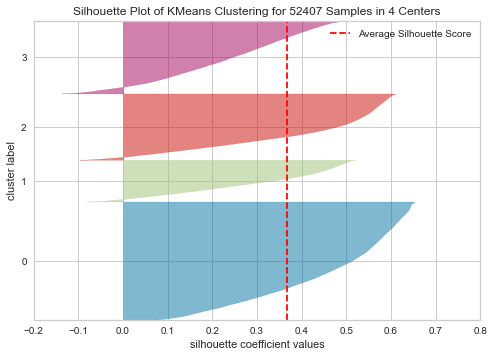

```
SilhouetteVisualizer(ax=<AxesSubplot:title={'center':'Silhouette Plot of KMeans Clustering for 52407 Samples in 4 Centers'}, xlabel='silhouette coefficient values', ylabel='cluster label'>,
                     colors='yellowbrick',
                     estimator=KMeans(n_clusters=4, random_state=43))
```

```python
from yellowbrick.cluster import silhouette_visualizer
silhouette_visualizer(KMeans(4, random_state=43), rfm_df, colors='yellowbrick')
```

## RFM Score

```python
rfm = df_clean_IQR[feature]
```

```python
bins_recency = [0,np.quantile(rfm['recency'],.33),np.quantile(rfm['recency'],.66),np.quantile(rfm['recency'],1)]
bins_frequency = [0,np.quantile(rfm['frequency'],.33),np.quantile(rfm['frequency'],.66),np.quantile(rfm['frequency'],1)]
bins_monetary = [0,np.quantile(rfm['monetary'],.33),np.quantile(rfm['monetary'],.66),np.quantile(rfm['monetary'],1)]
```

```python
rfm['recency_score']    = pd.cut(rfm['recency'], bins_recency, labels=[3, 2, 1], include_lowest=True)
rfm['frequency_score']  = pd.cut(rfm['frequency'], bins_frequency, labels=[1, 2,3], include_lowest=True)
rfm['monetary_score']   = pd.cut(rfm['monetary'], bins_monetary, labels=[1, 2, 3], include_lowest=True)
```

```python
rfm['recency_score']    = rfm.recency_score.astype(int)
rfm['frequency_score']  = rfm.frequency_score.astype(int)
rfm['monetary_score']   = rfm.monetary_score.astype(int)
rfm['rfm_score'] = rfm['recency_score'].map(str) + rfm['frequency_score'].map(str) + rfm['monetary_score'].map(str)
```

```python
rfm['rfm_score'] = rfm['rfm_score'].astype(int)
```

```python
url2 = "https://gitlab.com/priagungkhusuma/rfm_segmentation/-/raw/master/rfm_score_dim.csv"
rfm_score_reference = pd.read_csv(url2)
```

```python
rfm = rfm.merge(rfm_score_reference,how='left',on='rfm_score')
```

```python
rfm
```

|  | recency | frequency | monetary | recency_score | frequency_score | monetary_score | rfm_score | segment_name |
| --- | --- | --- | --- | --- | --- | --- | --- | --- |
| 0 | 51 | 12 | 12500.0 | 3 | 3 | 3 | 333 | CHAMPION |
| 1 | 22 | 18 | 7444.0 | 3 | 3 | 3 | 333 | CHAMPION |
| 2 | 22 | 14 | 0.0 | 3 | 3 | 1 | 331 | POTENTIAL LOYALIST |
| 3 | 13 | 23 | 12331.0 | 3 | 3 | 3 | 333 | CHAMPION |
| 4 | 5 | 13 | 11050.0 | 3 | 3 | 3 | 333 | CHAMPION |
| ... | ... | ... | ... | ... | ... | ... | ... | ... |
| 52402 | 435 | 2 | 0.0 | 1 | 1 | 1 | 111 | LOST CUSTOMER |
| 52403 | 295 | 2 | 0.0 | 1 | 1 | 1 | 111 | LOST CUSTOMER |
| 52404 | 87 | 4 | 0.0 | 2 | 1 | 1 | 211 | ABOUT TO SLEEP |
| 52405 | 28 | 2 | 0.0 | 3 | 1 | 1 | 311 | RECENT CUSTOMER |
| 52406 | 398 | 2 | 0.0 | 1 | 1 | 1 | 111 | LOST CUSTOMER |

52407 rows × 8 columns

## Modeling RFM Score

```python
rfm.iloc[:,3:6]
```

|  | recency_score | frequency_score | monetary_score |
| --- | --- | --- | --- |
| 0 | 3 | 3 | 3 |
| 1 | 3 | 3 | 3 |
| 2 | 3 | 3 | 1 |
| 3 | 3 | 3 | 3 |
| 4 | 3 | 3 | 3 |
| ... | ... | ... | ... |
| 52402 | 1 | 1 | 1 |
| 52403 | 1 | 1 | 1 |
| 52404 | 2 | 1 | 1 |
| 52405 | 3 | 1 | 1 |
| 52406 | 1 | 1 | 1 |

52407 rows × 3 columns

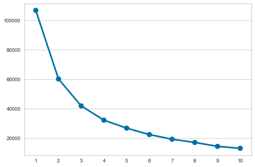

```python
from sklearn.cluster import KMeans
SSE = []
for k in range(0,10):
    kmeans = KMeans(n_clusters=k+1,random_state=43).fit(rfm.iloc[:,3:6])
    SSE.append(kmeans.inertia_)
sns.pointplot(x=list(range(1,11)),y=SSE)
plt.show()
```

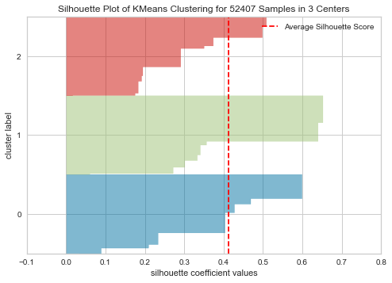

```
SilhouetteVisualizer(ax=<AxesSubplot:title={'center':'Silhouette Plot of KMeans Clustering for 52407 Samples in 3 Centers'}, xlabel='silhouette coefficient values', ylabel='cluster label'>,
                     colors='yellowbrick',
                     estimator=KMeans(n_clusters=3, random_state=43))
```

```python
from yellowbrick.cluster import silhouette_visualizer
silhouette_visualizer(KMeans(3, random_state=43), rfm.iloc[:,3:6], colors='yellowbrick')
```

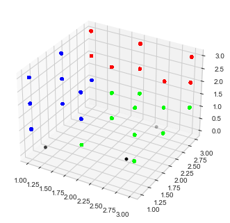

```python
model = KMeans(n_clusters=3,random_state=43).fit(rfm.iloc[:,3:6])
centers = model.cluster_centers_
fig = plt.figure()
ax = fig.add_subplot(111,projection='3d')
ax.scatter(rfm['recency_score'],rfm['frequency_score'],rfm['monetary_score'],
           c=model.predict(rfm.iloc[:,3:6]),cmap='brg')
ax.scatter(centers[:,0],centers[:,1],c='black')
```

[output not shown]

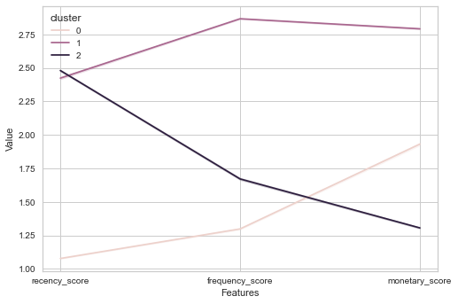

```python
rfm['cluster'] = model.labels_
melted_rfm = pd.melt(rfm.reset_index(),
                     id_vars = ['cluster'],
                    value_vars = ['recency_score','frequency_score','monetary_score'],
                    var_name = 'Features',value_name='Value')
sns.lineplot('Features','Value',hue='cluster',data=melted_rfm)
plt.legend
```

```python
rfm.groupby('cluster').agg({'recency':['mean','min','max'],'frequency':['mean','min','max']
                             ,'monetary':['mean','min','max','count']
}).reset_index()
```

|  | cluster | recency mean | recency min | recency max | frequency mean | frequency min | frequency max | monetary mean | monetary min | monetary max | monetary count |
| --- | --- | --- | --- | --- | --- | --- | --- | --- | --- | --- | --- |
| 0 | 0 | 347.472776 | 58 | 605 | 3.897426 | 2 | 27 | 2511.326363 | 0.0 | 12584.0 | 17558 |
| 1 | 1 | 80.852277 | 0 | 604 | 15.177704 | 5 | 31 | 6122.085636 | 1211.0 | 12590.0 | 17411 |
| 2 | 2 | 73.265168 | 0 | 192 | 5.796078 | 2 | 31 | 902.297282 | 0.0 | 12400.0 | 17438 |

**cluster 0 (Risk to Churn Customer)** :

RFM Characteristic:

```
1. sudah lama tidak bertransaksi
2. frequency terbang paling rendah
3. monetary nya rata-rata
```

Customer yang sudah lama tidak bertransaksi dengan jumlah penerbangan paling rendah. Customer ini mengeluarkan uang dengan jumlah rata-rata dari masing-masing cluster.

Action :

Meminta tim marketing untuk riset mengapa customer ini sudah lama tidak menggunakan maskapai kita. Promo untuk terbang kembali dengan tujuan dan harga yang sesuai dengan karakteristik.

**cluster 1 (Potential to be loyalist customer)**:

RFM Characteristic:

```
1. Recency sedang
2. Frequency tertinggi
3. Monetary tertinggi
```

Customer yang biasa terbang dengan maskapai kita dengan jumlah penerbangan yang banyak dan mengeluarkan uang paling banyak

Action:

Memberikan promo referal kepada pelanggan untuk mengajak kerabat atau teman untuk menggunakan maskapai kita.

**cluster 2 (Average Customer)**:

RFM Characteristic:

```
1. recency terendah
2. frequency sedang
3. monetary paling rendah
```

Customer yang paling sering menggunakan maskapai kita akan tetapi jarang melakukan penerbangan dan mengeluarkan uang paling sedikit.

Action :

Memberikan promo untuk penerbangan selanjutnya dengan waktu yang terbatas pada saat pembelian tiket (Loyalty Program).

**Business Insight**

[output not shown]

```python
df_clean_IQR['cluster'] = model.labels_
```